# Peripheral Cities

Brian Waters

Mar 25, 2024

# DANE Comparison

[output not shown]

# Overview: City-Regions, Municipalities, Units

Total Projects: 1,378

Total Units: 550,048

Included Municipalities: Barranquilla, Bello, Bogota, Cajicá, Caldas, Chía, Copacabana, Envigado, Funza, Galapa, Girardota, Itagüí, La Calera, La Estrella, Madrid, Malambo, Medellin, Mosquera, Sabaneta, Soacha, Soledad

Unit of analysis for data is apartment units.

Unit of analysis for mapping is project.

## Total Constructions

| Included Municipalities Only City-Region | Included Municipalities Only Municipality | Included Municipalities Only Projects | Included Municipalities Only Units |
| --- | --- | --- | --- |
| Bogota | Bogota | 538 | 208,918 |
| Bogota | Cajicá | 11 | 5,414 |
| Bogota | Chía | 12 | 5,133 |
| Bogota | Funza | 22 | 7,124 |
| Bogota | La Calera | 7 | 1,219 |
| Bogota | Madrid | 50 | 29,720 |
| Bogota | Mosquera | 41 | 15,504 |
| Bogota | Soacha | 283 | 121,226 |
| Barranquilla | Barranquilla | 67 | 34,327 |
| Barranquilla | Galapa | 3 | 3,337 |
| Barranquilla | Malambo | 2 | 248 |
| Barranquilla | Soledad | 97 | 34,032 |
| Medellin | Bello | 50 | 21,213 |
| Medellin | Caldas | 5 | 2,057 |
| Medellin | Copacabana | 9 | 1,651 |
| Medellin | Envigado | 3 | 1,912 |
| Medellin | Girardota | 3 | 506 |
| Medellin | Itagüí | 13 | 4,652 |
| Medellin | La Estrella | 8 | 3,068 |
| Medellin | Medellin | 143 | 43,580 |
| Medellin | Sabaneta | 11 | 5,207 |

## Construction over Time

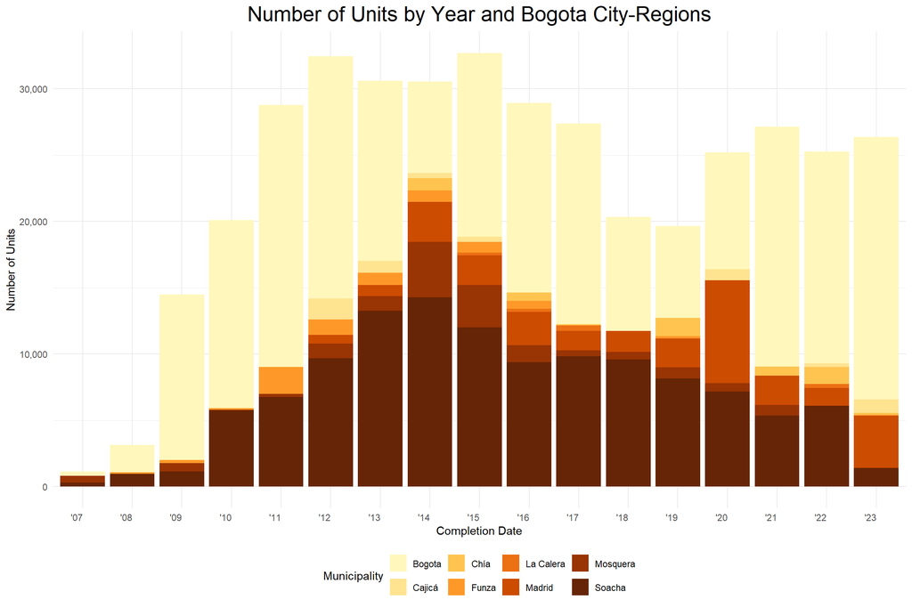

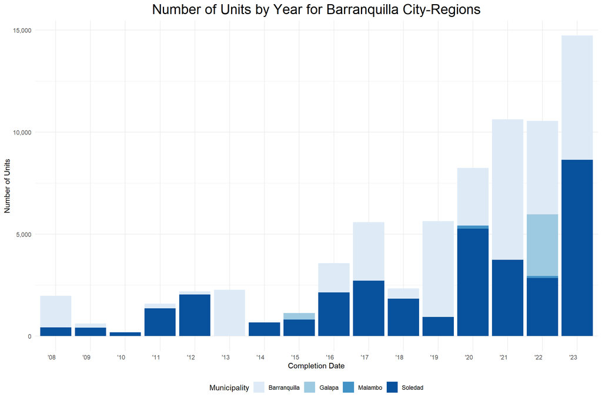

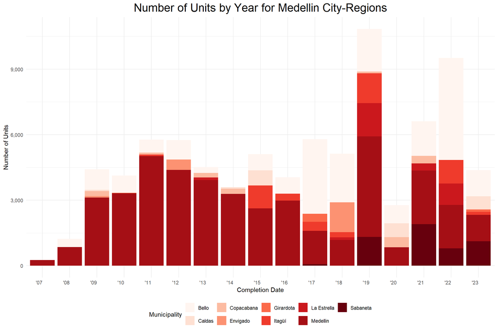

## Units Per Project

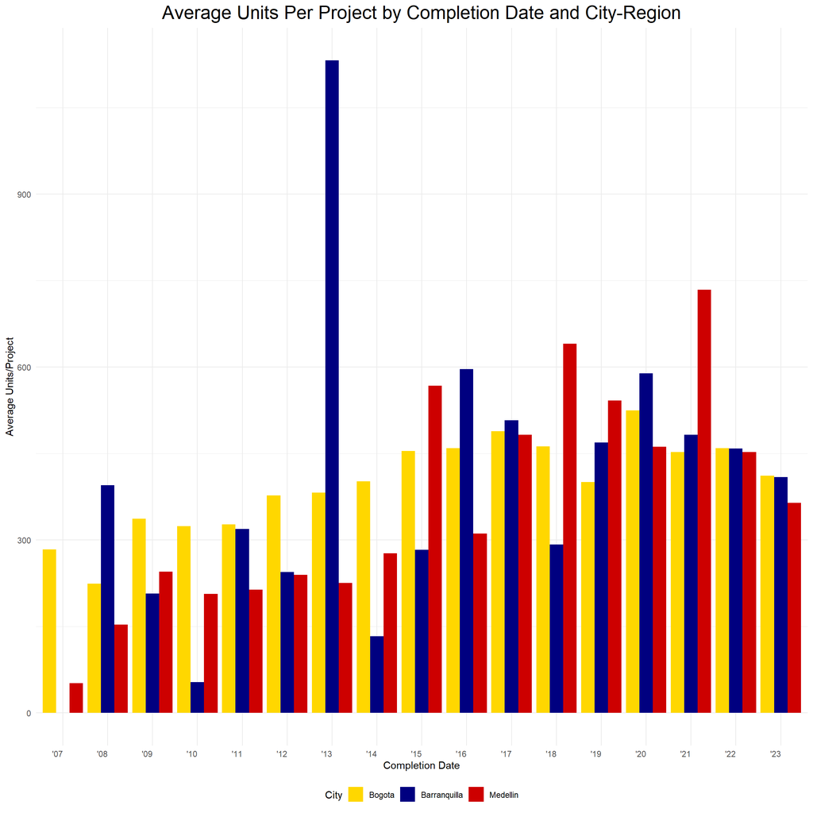

## Units Per City Growth

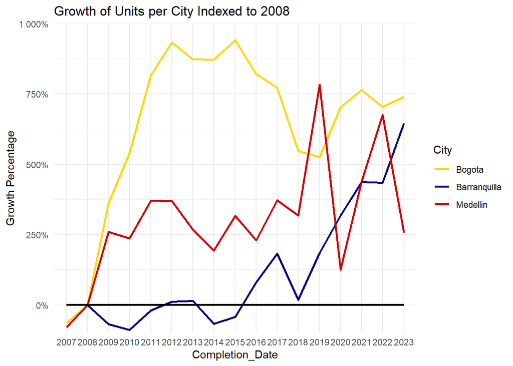

# Floors and Towers

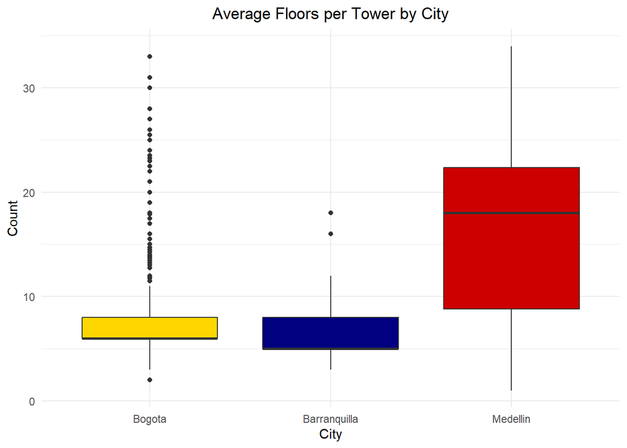

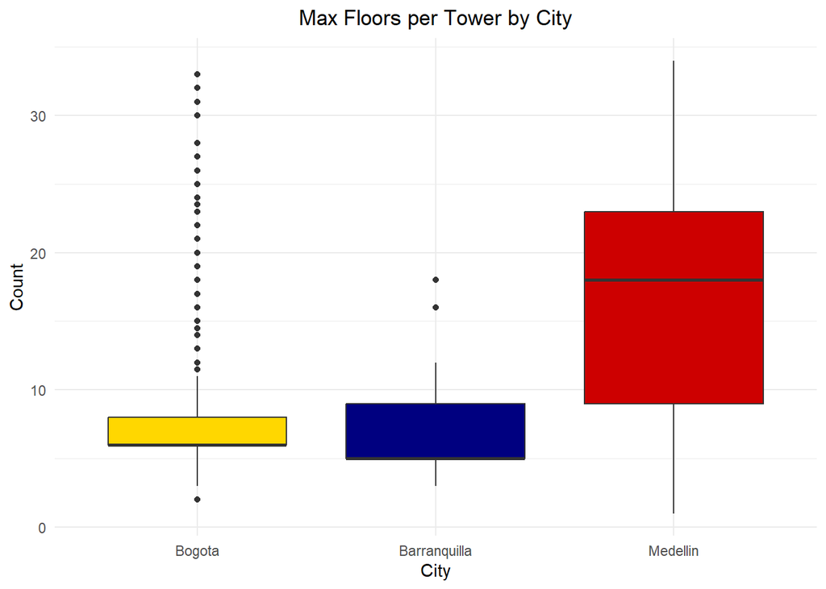

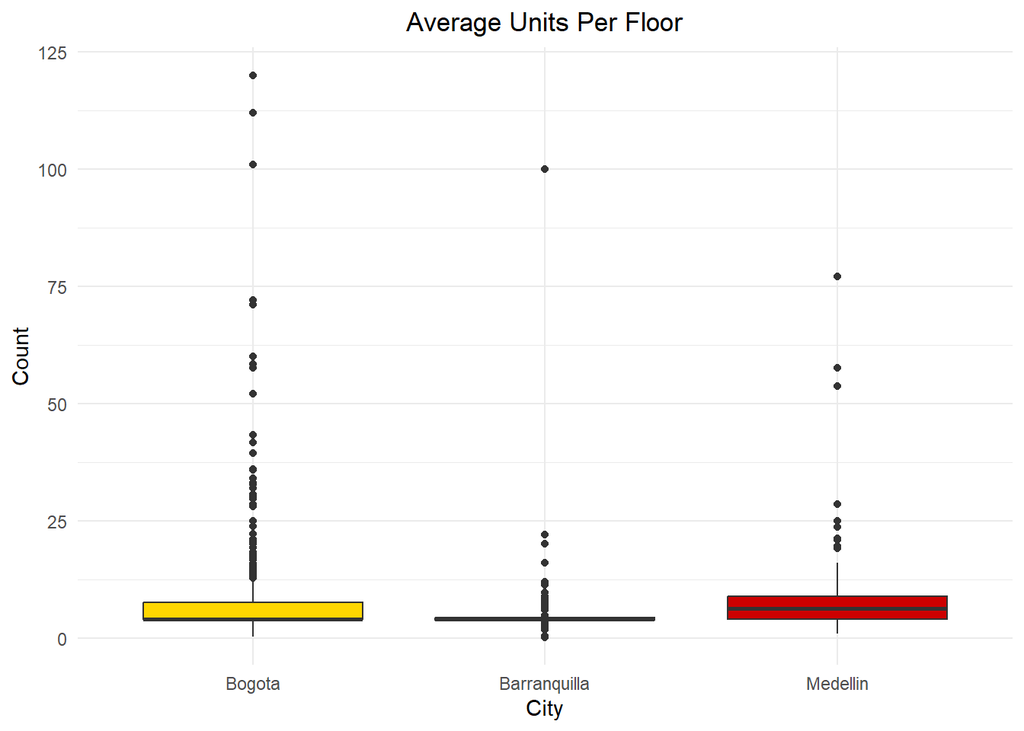

Projects with more than 20 Units per Floor

| Project_Code | Constructor | City | Project_Towers | Max_Floors | Units |
| --- | --- | --- | --- | --- | --- |
| 90202 | Const. Bolivar | Bogota | 8 | 6 | 2079 |
| 50783 | Inv. Edecios | Bogota | 10 | 6 | 1812 |
| 15765 | ACF SAS | Barranquilla | 3 | 5 | 1500 |
| 50557 | Const. Bolivar | Bogota | 4 | 6 | 1400 |
| 55131 | Apiros | Bogota | 2 | 6 | 1212 |
| 41550 | Buenvivir Cons. | Bogota | 1 | 28 | 1105 |
| 56007 | Apiros | Bogota | 5 | 6 | 984 |
| 61875 | ISC Inserco | Medellin | 4 | 11 | 933 |
| 55312 | Ingeurbe | Bogota | 2 | 6 | 852 |
| 56185 | Buenvivir Cons. | Bogota | 2 | 16 | 760 |
| 55281 | Const. Bolivar | Bogota | 2 | 6 | 720 |
| 90328 | Const. Bolivar | Bogota | 2 | 18 | 700 |
| 55253 | Const. Bolivar | Bogota | 1 | 6 | 672 |
| 90276 | Const. Bolivar | Bogota | 1 | 18 | 646 |
| 90287 | Const. Bolivar | Bogota | 3 | 7 | 643 |
| 407082 | Apiros | Bogota | 2 | 6 | 624 |
| 56009 | Apiros | Bogota | 4 | 6 | 600 |
| 31677 | Const. Capital | Bogota | 1 | 14 | 584 |
| 50637 | Const. Alcaparros | Bogota | 2 | 4 | 576 |
| 61318 | Prom. del Rio | Medellin | 3 | 11 | 560 |
| 56064 | Apiros | Bogota | 3 | 6 | 504 |
| 55217 | Const. Bolivar | Bogota | 2 | 2 | 480 |
| 41529 | Buenvivir Cons. | Bogota | 1 | 23 | 470 |
| 61511 | GIC Gerencia Inter y Consultoria | Medellin | 3 | 2 | 462 |
| 51059 | Impulsa Colombia | Bogota | 1 | 10 | 460 |
| 407145 | Apiros | Bogota | 2 | 6 | 432 |
| 60718 | Conaltura | Medellin | 4 | 2 | 429 |
| 55014 | Colsubsidio | Bogota | 4 | 5 | 420 |
| 407105 | Obycon | Bogota | 2 | 6 | 408 |
| 51029 | Los Sauces Construcciones | Bogota | 2 | 10 | 400 |
| 55082 | MYH Ingenieros | Bogota | 2 | 6 | 384 |
| 15699 | Castro Panesso | Barranquilla | 2 | 8 | 352 |
| 41557 | A.R. Const. | Bogota | 1 | 17 | 342 |
| 500017 | Obycon | Bogota | 3 | 5 | 300 |
| 50755 | Triada | Bogota | 2 | 6 | 240 |
| 60878 | Prom. Escala | Medellin | 2 | 2 | 230 |
| 61799 | Bienes y Bienes | Medellin | 5 | 2 | 208 |
| 41677 | Oikos | Bogota | 1 | 7 | 200 |
| 55294 | Pedro Gomez | Bogota | 1 | 6 | 198 |
| 41511 | Prom. Vivendum | Bogota | 1 | 8 | 177 |
| 60948 | Const. Capital | Medellin | 7 | 1 | 175 |
| 15893 | Cohala Construcciones | Barranquilla | 1 | 8 | 160 |
| 407118 | Ambientti | Bogota | 1 | 5 | 148 |
| 60876 | Prom. Escala | Medellin | 1 | 2 | 57 |

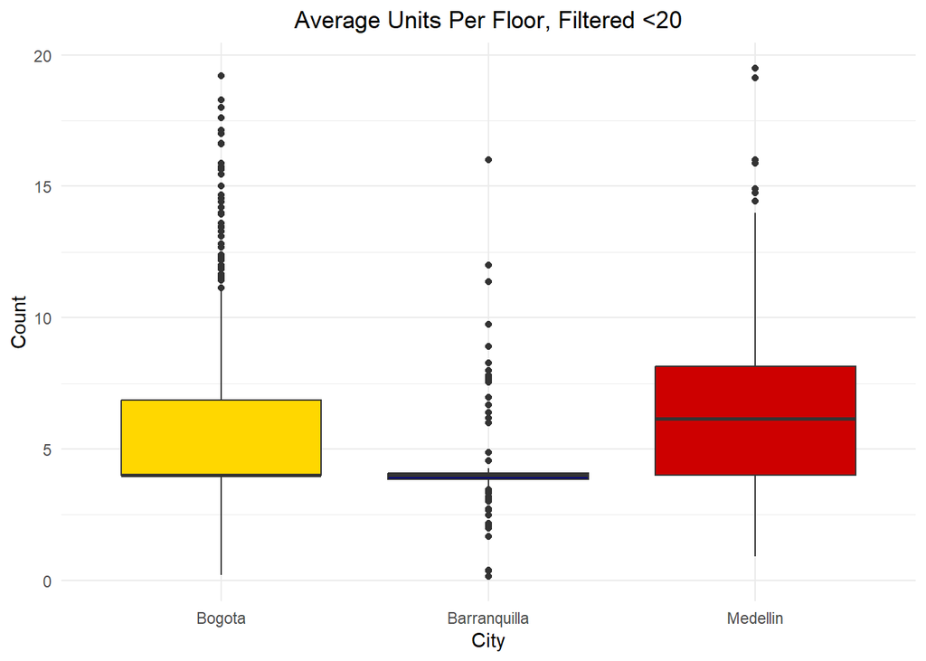

# Builder

| Projects and Units By Builder and City (Greater than 5,000 Units) City-Region | Projects and Units By Builder and City (Greater than 5,000 Units) Constructor | Projects and Units By Builder and City (Greater than 5,000 Units) Projects | Projects and Units By Builder and City (Greater than 5,000 Units) Units |
| --- | --- | --- | --- |
| Bogota | Const. Bolivar | 124 | 61,430 |
| Bogota | Apiros | 60 | 36,488 |
| Bogota | Const. Las Galias | 36 | 27,048 |
| Bogota | Amarilo | 70 | 24,684 |
| Bogota | Const. Capital | 33 | 17,853 |
| Bogota | Prodesa | 37 | 16,454 |
| Bogota | Marval | 29 | 13,713 |
| Bogota | A.R. Const. | 17 | 11,033 |
| Bogota | Mendebal | 19 | 9,627 |
| Bogota | Ingeurbe | 21 | 9,402 |
| Bogota | Const. Colpatria | 21 | 9,116 |
| Bogota | Urbansa | 22 | 8,295 |
| Bogota | Norco | 14 | 6,757 |
| Bogota | Triada | 21 | 6,660 |
| Bogota | Buenvivir Cons. | 11 | 6,397 |
| Bogota | Arq. & Concreto | 7 | 5,550 |
| Bogota | Inv. Alcabama | 9 | 5,474 |
| Barranquilla | Const. Bolivar | 32 | 16,018 |
| Barranquilla | Marval | 21 | 10,140 |
| Barranquilla | ACF SAS | 5 | 6,520 |
| Medellin | Conaltura | 24 | 10,158 |
| Medellin | Const. Capital | 23 | 9,775 |

## Builder Tier

Categories:

Teir 1 Constructors: More than 10,000 Units

Teir 2 Constructors: More than 1,000 Units

Tier 3 Constructors: More than 250 Units

Tier 4 Constructors: Less than 250 Units

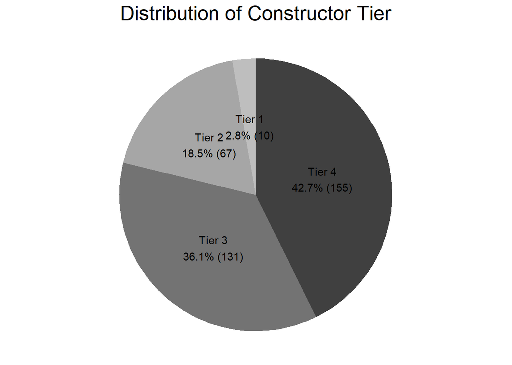

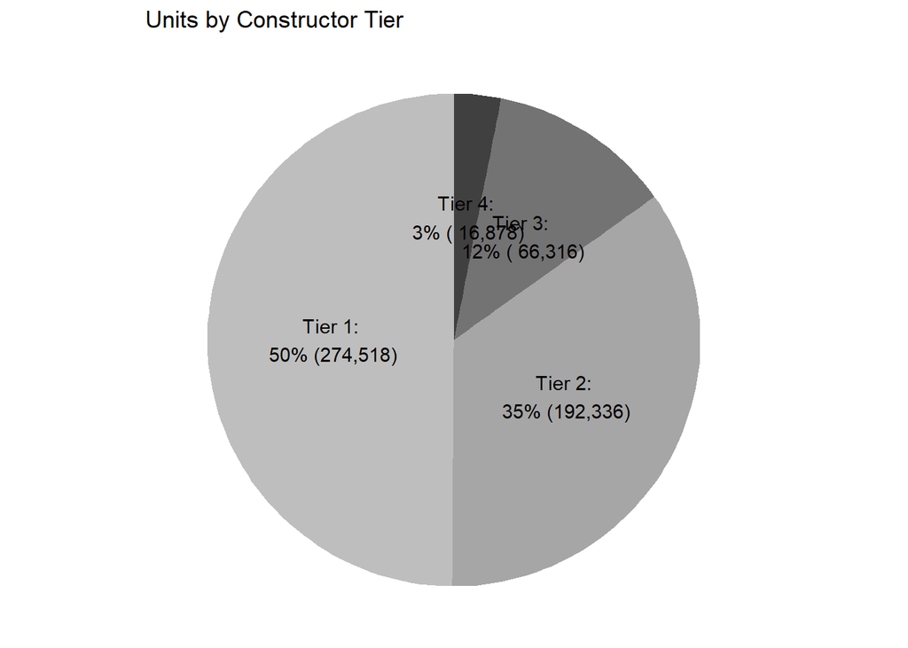

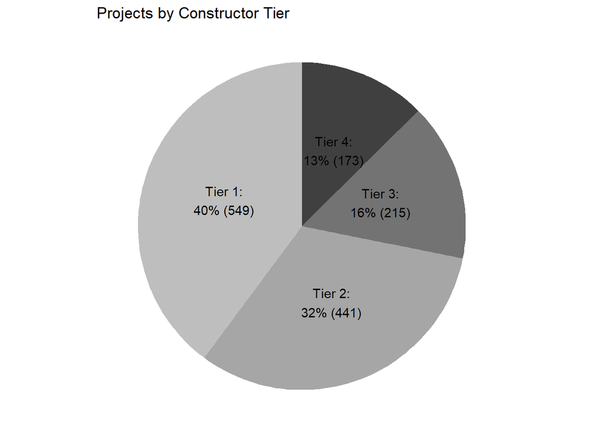

## Multi-City Builders

| Multi-City Constructors and Units Constructed Constructor | Multi-City Constructors and Units Constructed Medellin | Multi-City Constructors and Units Constructed Bogota | Multi-City Constructors and Units Constructed Barranquilla | Multi-City Constructors and Units Constructed Total_Units |
| --- | --- | --- | --- | --- |
| Const. Bolivar | 0 | 61,430 | 16,018 | 77,448 |
| Amarilo | 0 | 24,684 | 4,632 | 29,316 |
| Const. Capital | 9,775 | 17,853 | 0 | 27,628 |
| Marval | 0 | 13,713 | 10,140 | 23,853 |
| Prodesa | 0 | 16,454 | 3,192 | 19,646 |
| Conaltura | 10,158 | 288 | 1,080 | 11,526 |
| A.R. Const. | 0 | 11,033 | 200 | 11,233 |
| Const. Colpatria | 0 | 9,116 | 1,216 | 10,332 |
| Arq. & Concreto | 441 | 5,550 | 316 | 6,307 |
| Fund. Compartir | 600 | 4,501 | 0 | 5,101 |
| Coninsa Ramon H. | 1,064 | 3,066 | 574 | 4,704 |
| Acierto Inm. | 4,296 | 220 | 0 | 4,516 |
| Obycon | 0 | 3,228 | 1,216 | 4,444 |
| C.A.S.A | 1,135 | 728 | 0 | 1,863 |
| Conconcreto | 998 | 528 | 290 | 1,816 |
| Inacar | 0 | 1,068 | 394 | 1,462 |
| Convel | 0 | 760 | 144 | 904 |

## Project Size

Average Units per Project, per Constructor, Multiple City-Regions

| Constructor | Bogota | Barranquilla | Medellin |
| --- | --- | --- | --- |
| A.R. Const. | 649 | 200 | NA |
| Acierto Inm. | 220 | NA | 716 |
| Amarilo | 353 | 463 | NA |
| Arq. & Concreto | 793 | 316 | 220 |
| C.A.S.A | 364 | NA | 227 |
| Conaltura | 288 | 540 | 423 |
| Conconcreto | 528 | 290 | 250 |
| Coninsa Ramon H. | 438 | 191 | 213 |
| Const. Bolivar | 495 | 501 | NA |
| Const. Capital | 541 | NA | 425 |
| Const. Colpatria | 434 | 608 | NA |
| Convel | 760 | 144 | NA |
| Fund. Compartir | 346 | NA | 300 |
| Inacar | 178 | 394 | NA |
| Marval | 473 | 483 | NA |
| Obycon | 359 | 405 | NA |
| Prodesa | 445 | 532 | NA |

[figure not shown]

[figure not shown]

[figure not shown]

[figure not shown]

## Builders by Floors

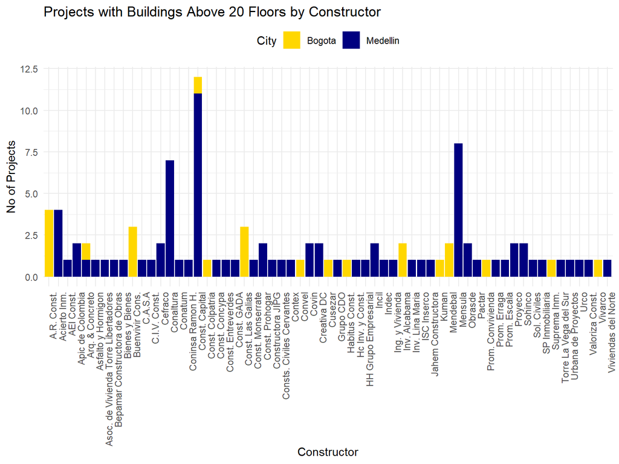

## Construction Over Time

[figure not shown]

# Stratum

## Stratum by Builder

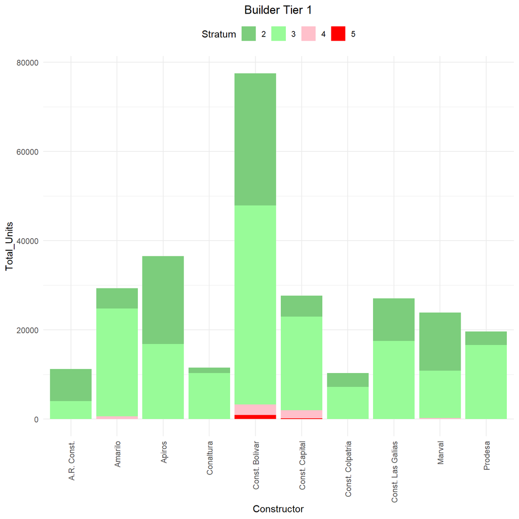

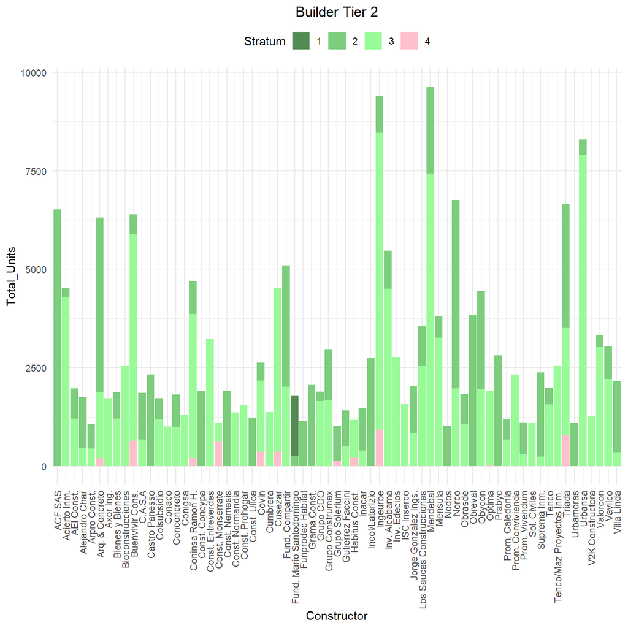

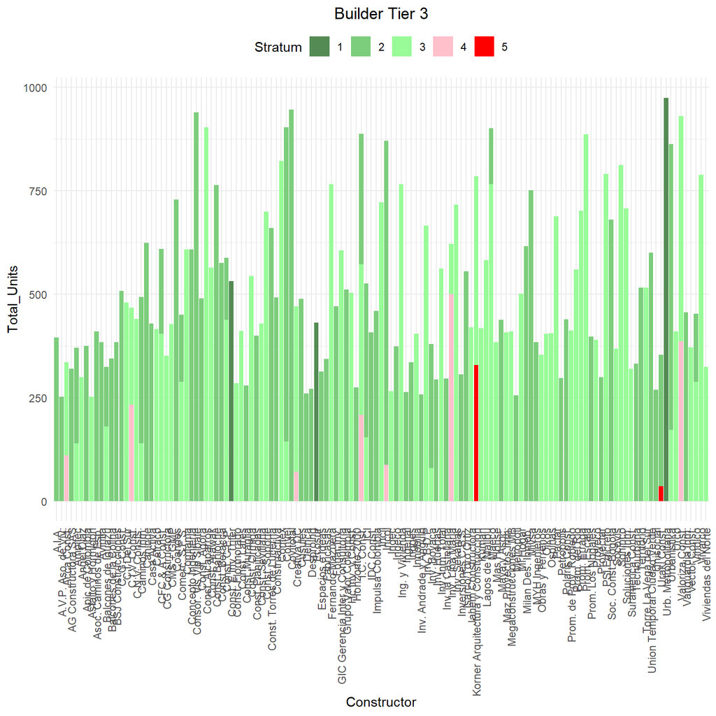

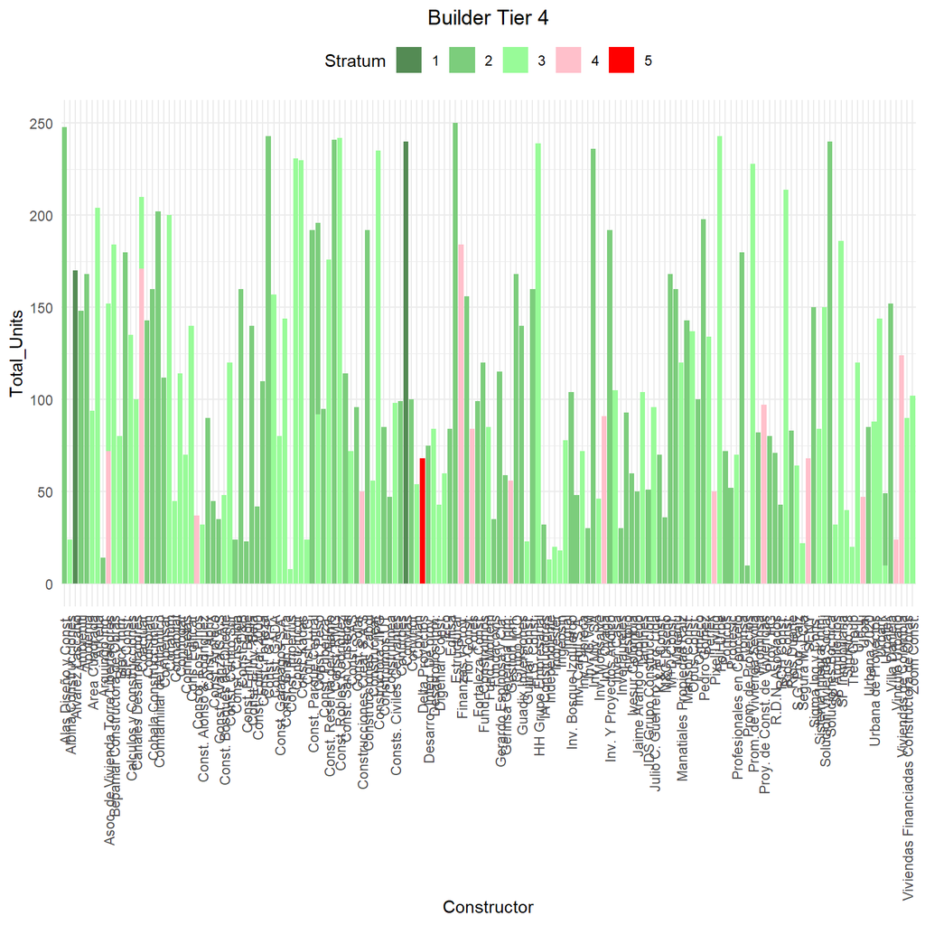

## Stratum by City

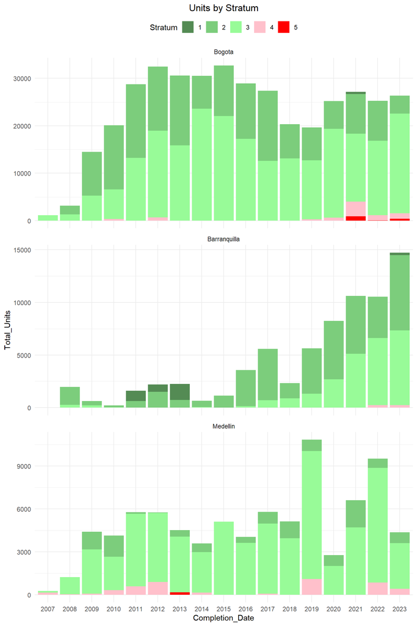

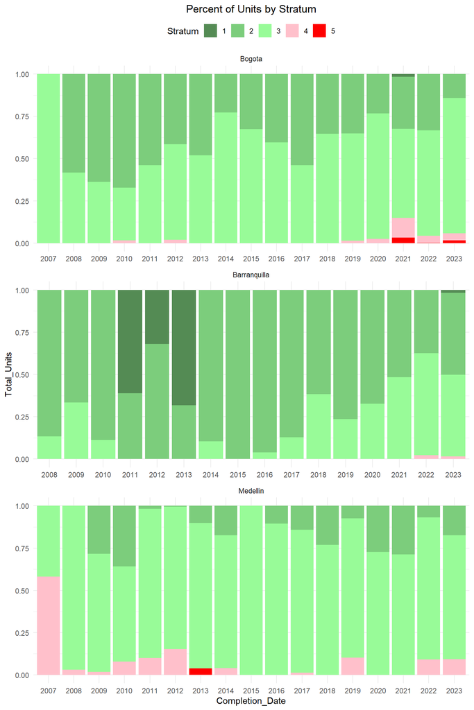

# Financier

## Financier by City-Region

| Multi-City Financiers Trustee | Multi-City Financiers Bogota | Multi-City Financiers Barranquilla | Multi-City Financiers Medellin | Multi-City Financiers Total_Units |
| --- | --- | --- | --- | --- |
| Bogotá | 174,939 | 22,676 | 8,205 | 205,820 |
| Davivienda | 103,050 | 17,030 | 3,439 | 123,519 |
| Alianza | 35,810 | 7,695 | 14,771 | 58,276 |
| No | 20,476 | 19,625 | 11,519 | 51,620 |
| Colmena | 30,737 | 420 | 0 | 31,157 |
| Acción | 3,370 | 1,457 | 22,475 | 27,302 |
| Bancolombia | 7,823 | 840 | 7,145 | 15,808 |
| Corficolombiana | 277 | 394 | 8,838 | 9,509 |
| Credicorp Capital | 4,690 | 645 | 3,001 | 8,336 |
| Colpatria | 4,928 | 960 | 344 | 6,232 |
| Occidente | 4,778 | 0 | 0 | 4,778 |
| Central | 2,017 | 0 | 2,077 | 4,094 |
| BBVA | 455 | 0 | 696 | 1,151 |
| Itaú | 0 | 0 | 500 | 500 |
| Valle | 0 | 0 | 412 | 412 |
| La Previsora | 335 | 0 | 0 | 335 |
| NA | 308 | 0 | 0 | 308 |
| Popular | 0 | 0 | 224 | 224 |
| Desistido | 0 | 202 | 0 | 202 |
| Fiduagraria | 0 | 0 | 200 | 200 |
| Corfisura | 180 | 0 | 0 | 180 |
| Petrol | 85 | 0 | 0 | 85 |

## Financier by Project Size

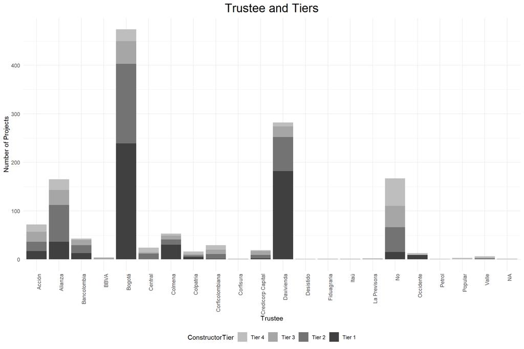

## Financiers and Constructors

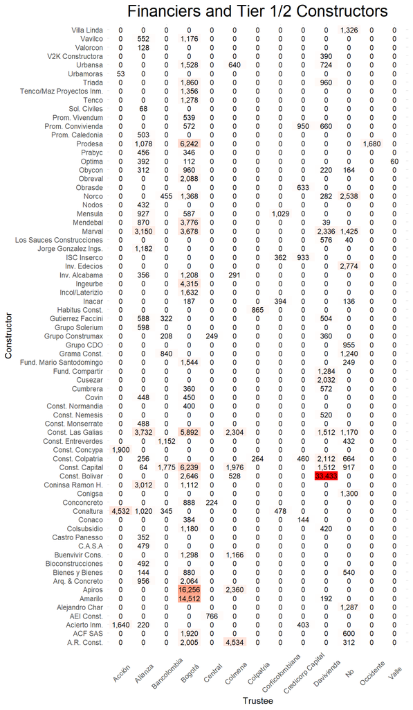

# VIS NVIS

## Counts

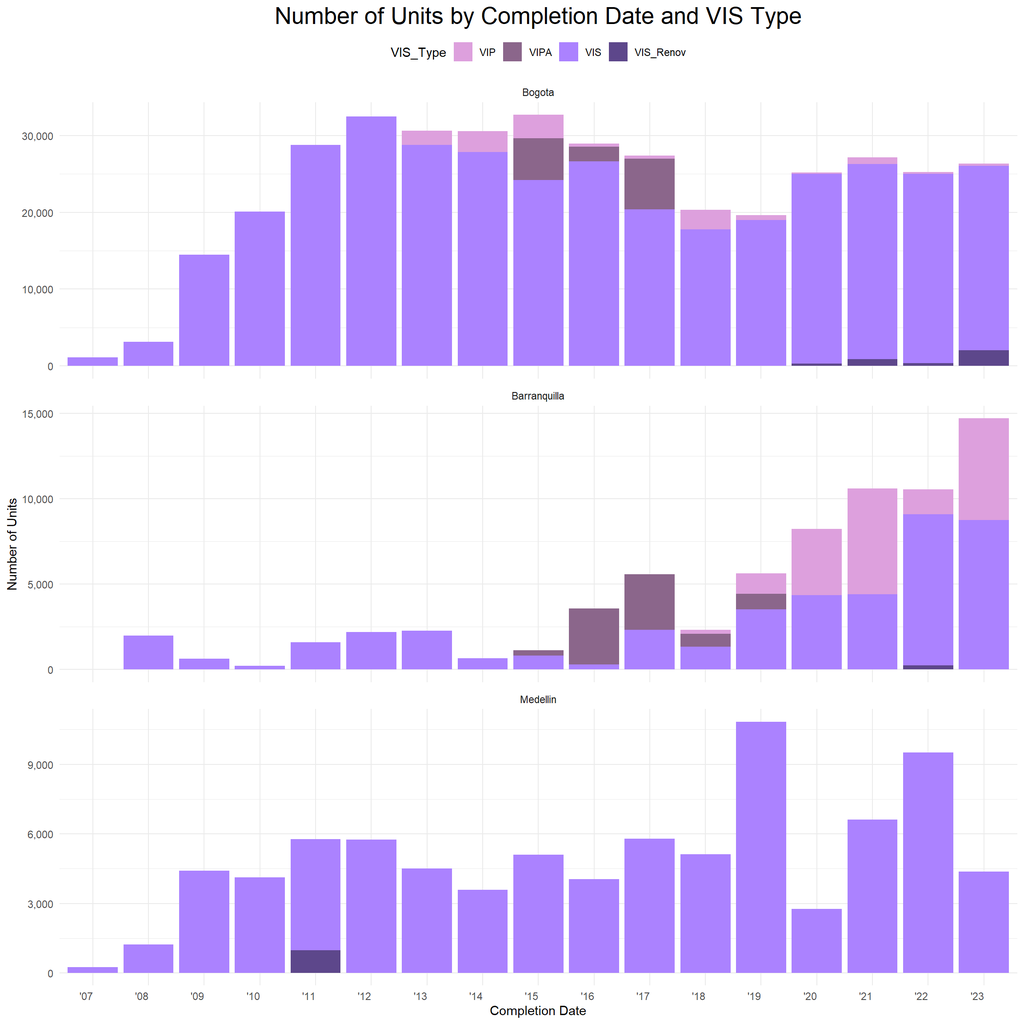

## Percentages

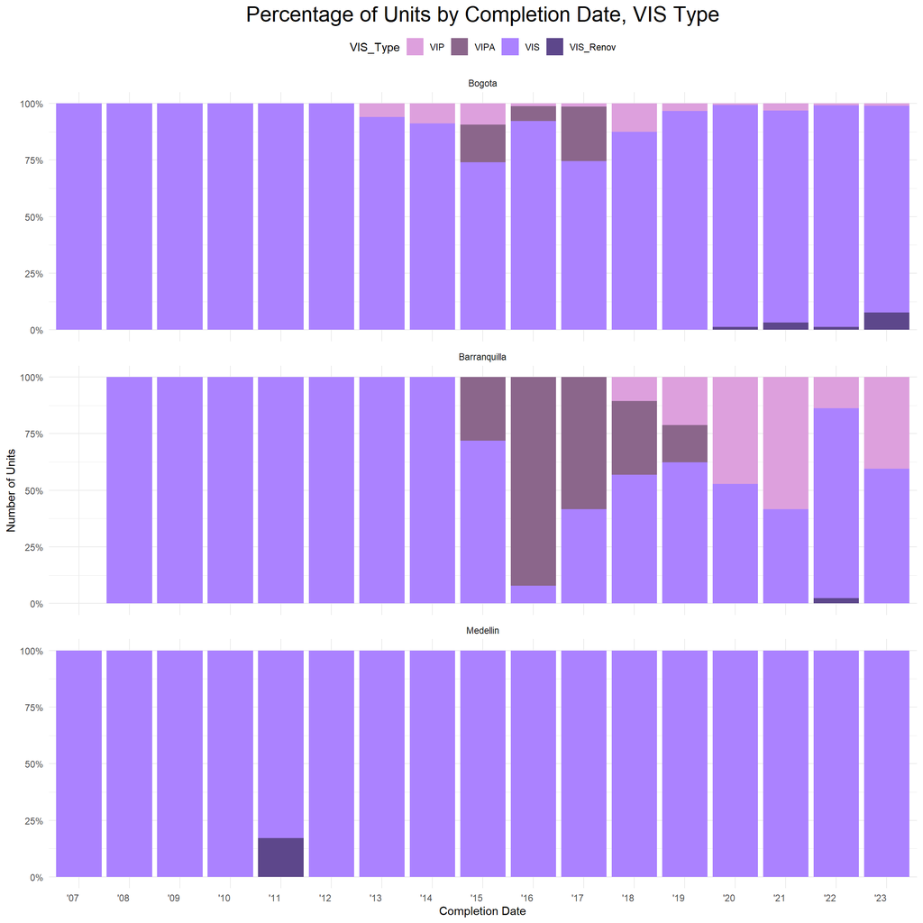

# Distance to Amenities

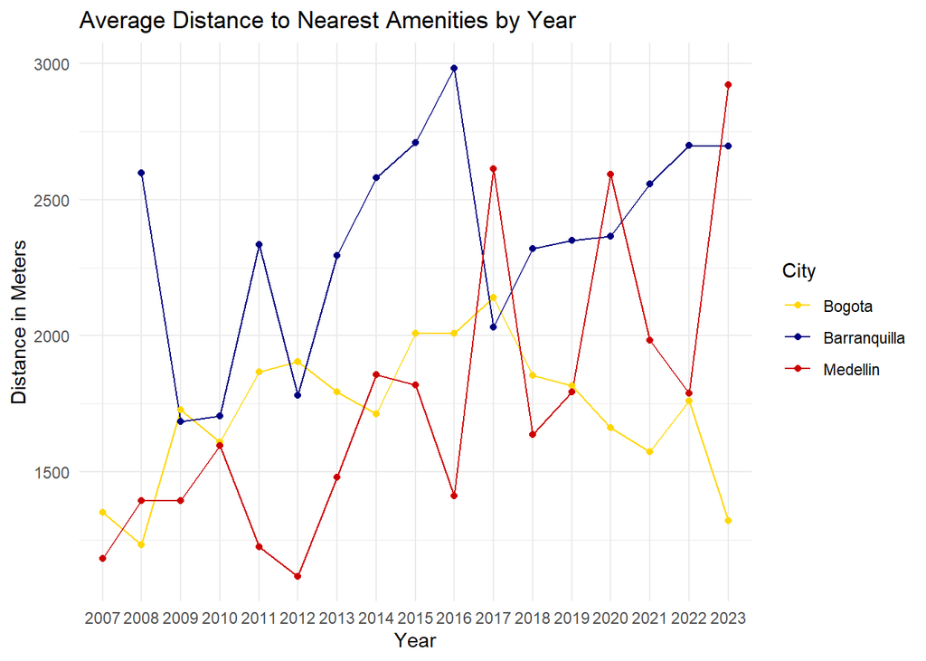

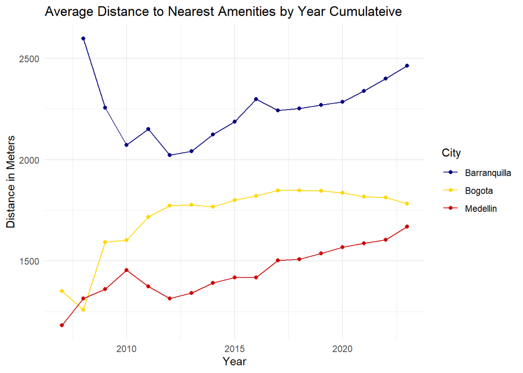

# Data Appendices:

## Appendix 1: All Stats

| **Characteristic** | **Overall**, N = 1,378<sup>1</sup> | **Bogota**, N = 964<sup>1</sup> | **Barranquilla**, N = 169<sup>1</sup> | **Medellin**, N = 245<sup>1</sup> |
| --- | --- | --- | --- | --- |
| ConstructorTier |  |  |  |  |
| Tier 4 | 173 (13%) | 99 (10%) | 24 (14%) | 50 (20%) |
| Tier 3 | 215 (16%) | 131 (14%) | 21 (12%) | 63 (26%) |
| Tier 2 | 441 (32%) | 306 (32%) | 50 (30%) | 85 (35%) |
| Tier 1 | 549 (40%) | 428 (44%) | 74 (44%) | 47 (19%) |
| Completion_Date |  |  |  |  |
| 2007 | 9 (0.7%) | 4 (0.4%) | 0 (0%) | 5 (2.0%) |
| 2008 | 27 (2.0%) | 14 (1.5%) | 5 (3.0%) | 8 (3.3%) |
| 2009 | 64 (4.6%) | 43 (4.5%) | 3 (1.8%) | 18 (7.3%) |
| 2010 | 86 (6.2%) | 62 (6.4%) | 4 (2.4%) | 20 (8.2%) |
| 2011 | 120 (8.7%) | 88 (9.1%) | 5 (3.0%) | 27 (11%) |
| 2012 | 119 (8.6%) | 86 (8.9%) | 9 (5.3%) | 24 (9.8%) |
| 2013 | 102 (7.4%) | 80 (8.3%) | 2 (1.2%) | 20 (8.2%) |
| 2014 | 94 (6.8%) | 76 (7.9%) | 5 (3.0%) | 13 (5.3%) |
| 2015 | 85 (6.2%) | 72 (7.5%) | 4 (2.4%) | 9 (3.7%) |
| 2016 | 82 (6.0%) | 63 (6.5%) | 6 (3.6%) | 13 (5.3%) |
| 2017 | 79 (5.7%) | 56 (5.8%) | 11 (6.5%) | 12 (4.9%) |
| 2018 | 60 (4.4%) | 44 (4.6%) | 8 (4.7%) | 8 (3.3%) |
| 2019 | 81 (5.9%) | 49 (5.1%) | 12 (7.1%) | 20 (8.2%) |
| 2020 | 68 (4.9%) | 48 (5.0%) | 14 (8.3%) | 6 (2.4%) |
| 2021 | 91 (6.6%) | 60 (6.2%) | 22 (13%) | 9 (3.7%) |
| 2022 | 99 (7.2%) | 55 (5.7%) | 23 (14%) | 21 (8.6%) |
| 2023 | 112 (8.1%) | 64 (6.6%) | 36 (21%) | 12 (4.9%) |
| Stratum |  |  |  |  |
| 1 | 6 (0.4%) | 1 (0.1%) | 5 (3.0%) | 0 (0%) |
| 2 | 502 (36%) | 371 (38%) | 104 (62%) | 27 (11%) |
| 3 | 810 (59%) | 562 (58%) | 57 (34%) | 191 (78%) |
| 4 | 55 (4.0%) | 26 (2.7%) | 3 (1.8%) | 26 (11%) |
| 5 | 5 (0.4%) | 4 (0.4%) | 0 (0%) | 1 (0.4%) |
| StratumFake |  |  |  |  |

[output cut: 423 more lines]

## Appendix 2: Full List of Included Municipalities, Projects and Units

Included Municipalities Bolded, Excluded Not Bold

| City | Municipality | Projects | Units |
| --- | --- | --- | --- |
| Bogota | **Bogota** | 538 | 208,918 |
| Bogota | **Cajicá** | 11 | 5,414 |
| Bogota | **Chía** | 12 | 5,133 |
| Bogota | Facatativa | 22 | 7,283 |
| Bogota | **Funza** | 22 | 7,124 |
| Bogota | Gachancipá | 9 | 2,320 |
| Bogota | **La Calera** | 7 | 1,219 |
| Bogota | **Madrid** | 50 | 29,720 |
| Bogota | **Mosquera** | 41 | 15,504 |
| Bogota | Nemocon | 2 | 768 |
| Bogota | **Soacha** | 283 | 121,226 |
| Bogota | Sopó | 2 | 604 |
| Bogota | Tabio | 2 | 624 |
| Bogota | Tenjo | 1 | 352 |
| Bogota | Tocancipá | 20 | 11,700 |
| Bogota | Zipaquirá | 39 | 13,512 |
| Barranquilla | **Barranquilla** | 67 | 34,327 |
| Barranquilla | **Galapa** | 3 | 3,337 |
| Barranquilla | **Malambo** | 2 | 248 |
| Barranquilla | **Soledad** | 97 | 34,032 |
| Medellin | **Bello** | 50 | 21,213 |
| Medellin | **Caldas** | 5 | 2,057 |
| Medellin | **Copacabana** | 9 | 1,651 |
| Medellin | El Carmen de Viboral | 3 | 251 |
| Medellin | **Envigado** | 3 | 1,912 |
| Medellin | **Girardota** | 3 | 506 |
| Medellin | Guarne | 2 | 542 |
| Medellin | **Itagüí** | 13 | 4,652 |
| Medellin | La Ceja | 11 | 3,303 |
| Medellin | **La Estrella** | 8 | 3,068 |
| Medellin | La Union | 1 | 60 |
| Medellin | **Medellin** | 143 | 43,580 |
| Medellin | Rionegro | 17 | 4,672 |
| Medellin | **Sabaneta** | 11 | 5,207 |
| Medellin | Santa Fé de Antioquia | 1 | 100 |
| Medellin | Sopetrán | 3 | 136 |

## Appendix 3: Projects and Units by Builder and City

Projects and Units By Builder and City

| City | Constructor | Projects | Units |
| --- | --- | --- | --- |
| Bogota | Const. Bolivar | 124 | 61,430 |
| Bogota | Apiros | 60 | 36,488 |
| Bogota | Const. Las Galias | 36 | 27,048 |
| Bogota | Amarilo | 70 | 24,684 |
| Bogota | Const. Capital | 33 | 17,853 |
| Bogota | Prodesa | 37 | 16,454 |
| Bogota | Marval | 29 | 13,713 |
| Bogota | A.R. Const. | 17 | 11,033 |
| Bogota | Mendebal | 19 | 9,627 |
| Bogota | Ingeurbe | 21 | 9,402 |
| Bogota | Const. Colpatria | 21 | 9,116 |
| Bogota | Urbansa | 22 | 8,295 |
| Bogota | Norco | 14 | 6,757 |
| Bogota | Triada | 21 | 6,660 |
| Bogota | Buenvivir Cons. | 11 | 6,397 |
| Bogota | Arq. & Concreto | 7 | 5,550 |
| Bogota | Inv. Alcabama | 9 | 5,474 |
| Bogota | Cusezar | 15 | 4,513 |
| Bogota | Fund. Compartir | 13 | 4,501 |
| Bogota | Obreval | 11 | 3,832 |
| Bogota | Los Sauces Construcciones | 8 | 3,550 |
| Bogota | Obycon | 9 | 3,228 |
| Bogota | Coninsa Ramon H. | 7 | 3,066 |
| Bogota | Vavilco | 9 | 3,048 |
| Bogota | Grupo Construmax | 12 | 2,974 |
| Bogota | Prabyc | 4 | 2,812 |
| Bogota | Inv. Edecios | 2 | 2,774 |
| Bogota | Incol/Laterizio | 7 | 2,736 |
| Bogota | Tenco/Maz Proyectos Inm. | 6 | 2,556 |
| Bogota | Bioconstrucciones | 8 | 2,547 |

[output cut: 354 more lines]

## Appendix 4: Average Units per Project per City by Builder

Average Units per Project, per Constructor, per City

| Constructor | Bogota | Barranquilla | Medellin |
| --- | --- | --- | --- |
| A.R. Const. | 649 | 200 | NA |
| A.V.P. Aso. de Viv. | 252 | NA | NA |
| Acierto Inm. | 220 | NA | 716 |
| Albina Construcciones | 24 | NA | NA |
| Amarilo | 353 | 463 | NA |
| Ambientti | 148 | NA | NA |
| Ampitec | 124 | NA | NA |
| Angel Diaz | 300 | NA | NA |
| Apiros | 608 | NA | NA |
| Apotema | 168 | NA | NA |
| Area Cuadrada | 94 | NA | NA |
| Arketia | 204 | NA | NA |
| Arpro Const. | 358 | NA | NA |
| Arq. & Concreto | 793 | 316 | 220 |
| Arquingo Ing. | 14 | NA | NA |
| Asoc. Caminos de Esp. | 410 | NA | NA |
| Avintia | 384 | NA | NA |
| BP Const. | 180 | NA | NA |
| Balcones de Iguazu | 162 | NA | NA |
| Bioconstrucciones | 318 | NA | NA |
| Buenvivir Cons. | 582 | NA | NA |
| C. G. Const. | 254 | NA | NA |
| C.A.S.A | 364 | NA | 227 |
| C.N.V. Consts. | 220 | NA | NA |
| CFC & A Const. | 203 | NA | NA |
| CG Constructora | 352 | NA | NA |
| CMS + GMP | 428 | NA | NA |
| Caminos Inm. | 165 | NA | NA |
| Canales Desarrolladores | 100 | NA | NA |
| Caninde | 624 | NA | NA |

[output cut: 333 more lines]

## Appendix 5: VIS By City

Type of VIS by City and Year

| City | Completion_Date | VIS | VIP | VIPA | VIS_Renov |
| --- | --- | --- | --- | --- | --- |
| Bogota | 2007 | 1,135 | 0 | 0 | 0 |
| Bogota | 2008 | 3,142 | 0 | 0 | 0 |
| Bogota | 2009 | 14,494 | 0 | 0 | 0 |
| Bogota | 2010 | 20,098 | 0 | 0 | 0 |
| Bogota | 2011 | 28,781 | 0 | 0 | 0 |
| Bogota | 2012 | 32,465 | 0 | 0 | 0 |
| Bogota | 2013 | 28,764 | 1,836 | 0 | 0 |
| Bogota | 2014 | 27,838 | 2,716 | 0 | 0 |
| Bogota | 2015 | 24,217 | 3,088 | 5,408 | 0 |
| Bogota | 2016 | 26,652 | 384 | 1,892 | 0 |
| Bogota | 2017 | 20,409 | 384 | 6,585 | 0 |
| Bogota | 2018 | 17,766 | 2,572 | 0 | 0 |
| Bogota | 2019 | 18,975 | 666 | 0 | 0 |
| Bogota | 2020 | 24,696 | 202 | 0 | 309 |
| Bogota | 2021 | 25,375 | 879 | 0 | 900 |
| Bogota | 2022 | 24,694 | 240 | 0 | 338 |
| Bogota | 2023 | 24,041 | 281 | 0 | 2,036 |
| Barranquilla | 2008 | 1,975 | 0 | 0 | 0 |
| Barranquilla | 2009 | 622 | 0 | 0 | 0 |
| Barranquilla | 2010 | 214 | 0 | 0 | 0 |
| Barranquilla | 2011 | 1,596 | 0 | 0 | 0 |
| Barranquilla | 2012 | 2,199 | 0 | 0 | 0 |
| Barranquilla | 2013 | 2,264 | 0 | 0 | 0 |
| Barranquilla | 2014 | 664 | 0 | 0 | 0 |
| Barranquilla | 2015 | 814 | 0 | 318 | 0 |
| Barranquilla | 2016 | 280 | 0 | 3,300 | 0 |
| Barranquilla | 2017 | 2,321 | 0 | 3,265 | 0 |
| Barranquilla | 2018 | 1,328 | 249 | 760 | 0 |
| Barranquilla | 2019 | 3,511 | 1,200 | 920 | 0 |
| Barranquilla | 2020 | 4,350 | 3,895 | 0 | 0 |
| Barranquilla | 2021 | 4,419 | 6,202 | 0 | 0 |
| Barranquilla | 2022 | 8,841 | 1,460 | 0 | 247 |
| Barranquilla | 2023 | 8,770 | 5,960 | 0 | 0 |
| Medellin | 2007 | 258 | 0 | 0 | 0 |
| Medellin | 2008 | 1,227 | 0 | 0 | 0 |
| Medellin | 2009 | 4,414 | 0 | 0 | 0 |
| Medellin | 2010 | 4,131 | 0 | 0 | 0 |
| Medellin | 2011 | 4,782 | 0 | 0 | 990 |
| Medellin | 2012 | 5,754 | 0 | 0 | 0 |
| Medellin | 2013 | 4,512 | 0 | 0 | 0 |
| Medellin | 2014 | 3,597 | 0 | 0 | 0 |
| Medellin | 2015 | 5,108 | 0 | 0 | 0 |
| Medellin | 2016 | 4,050 | 0 | 0 | 0 |
| Medellin | 2017 | 5,793 | 0 | 0 | 0 |
| Medellin | 2018 | 5,123 | 0 | 0 | 0 |
| Medellin | 2019 | 10,840 | 0 | 0 | 0 |
| Medellin | 2020 | 2,770 | 0 | 0 | 0 |
| Medellin | 2021 | 6,609 | 0 | 0 | 0 |
| Medellin | 2022 | 9,511 | 0 | 0 | 0 |
| Medellin | 2023 | 4,377 | 0 | 0 | 0 |

# Data Cleanup:

## Project Towers

Towers: decided by creating three columns, the sum, and max of “Number of Towers Column, and also extracting the max number from tower description. When two or all three of these agreed, that was the number. After that, I took the largest number of the three that was between 0 and 100. If both of these failed, the value was removed. This created 152 NAs out of 1222

Units: added up all units from each stage of the project

Value: added up all units from each stage of the project

Area: added up all units from each stage of the project

Floors: added up all units from each stage of the project

Completion date was filtered by year, eliminating 3 projects pre 2007

## Initial_Down_Payment_Percentage

1, 1.1, 1.4 = .1, .11, .14 30=.3, 40=.4

## Delivery _Type

Acabados = ‘Acabados/’,‘Acabados/Obra Gris/’

Semi Acabados = ‘Acabados/Semi Acabados/’, ‘Obra Gris/Semi Acabados/’, ‘Semi Acabados/’

Obra Gris = Obra Gris/’

## Partial_or_Total_Trustee

No: ‘0’, ‘No’, ‘No Aplica’, ‘No tiene’, ‘No Tiene’ Parcial: ‘parcial’, ‘Parcial’ Total: ‘total’, ‘Total’